# Bootstrap、信賴區間與效果量

Week 05 Part 2  
回到 Week 05 Index

HT3001B 生物統計學與 R

2026-10-08

## 點估計像魚叉，區間像漁網

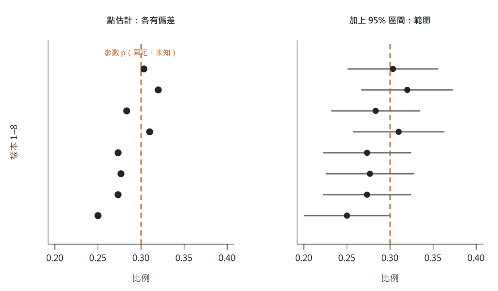

8份樣本（p等於0.30、n等於300）。左圖只畫各樣本的比例，都偏離橘色虛線的真實參數；右圖加上95%區間，多數區間跨過虛線。

參數是固定的未知量；點估計（point estimate）是一個數，信賴區間（confidence interval，CI）給出一個範圍。

IMS §12.3.1；本課程自製模擬（p=0.30、n=300，8份樣本，seed=71）；虛線為固定的參數，區間由樣本算出

## 點估計與區間估計

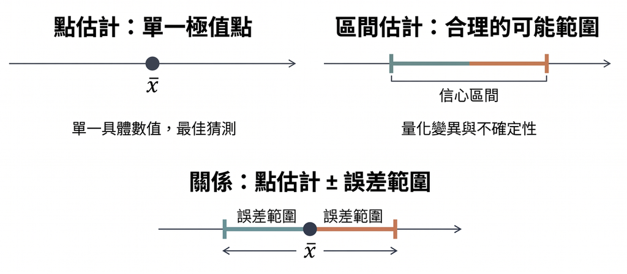

三個示意圖。左上是點估計：數線上的一個點，標為樣本平均數，說明為單一具體數值、最佳猜測。右上是區間估計：數線上的一段範圍，標為信心區間，說明為量化變異與不確定性。下方是兩者的關係：以點估計為中心，左右各加一段誤差範圍。

區間估計（interval estimate）常寫成「點估計 ± 誤差範圍」；信心區間即信賴區間。

本課程示意圖；概念對照 IMS §12.3.1

## 回到民調：估計值與 SE

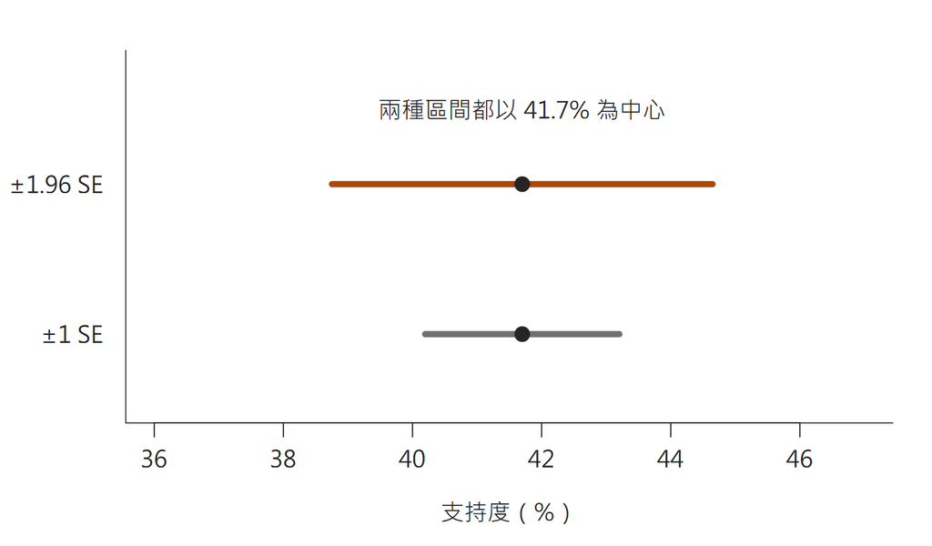

以41.7%為中心，±1SE較窄，常態近似±1.96SE較寬；簡單模型示意。

估計值 ± 1.96×SE，就是信賴區間的雛形；中位數沒有簡單的 SE 公式，接下來用重抽樣求。

IMS §13.3.2–13.3.3、§16.2；簡單模型，非正式民調區間；同 Part 1 民調示範

## 自助重抽樣（bootstrap）的想法

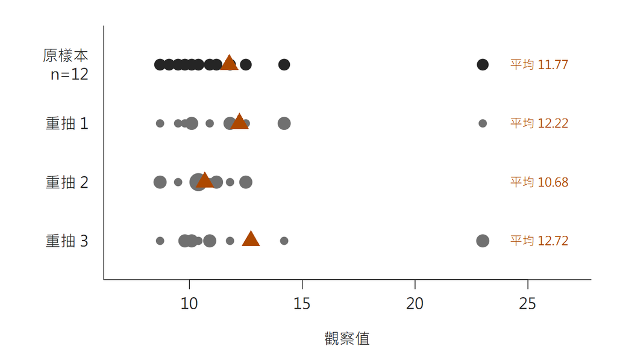

最上列是原始12筆樣本，橘色三角形是平均11.77；下面三列是三次重抽，點越大表示該值被抽到多次，三次重抽的平均分別為12.22、10.68、12.72。

只有一份樣本時，把它當成母體的縮影，從樣本中重抽，看統計量會怎麼變。

IMS §12.1.2；本課程自編12筆示範資料（9.1、10.4、11.8、8.7、14.2、10.9、12.5、9.8、23.0、10.1、11.2、9.5）；圖為自製

## 母體未知：用樣本估計母體

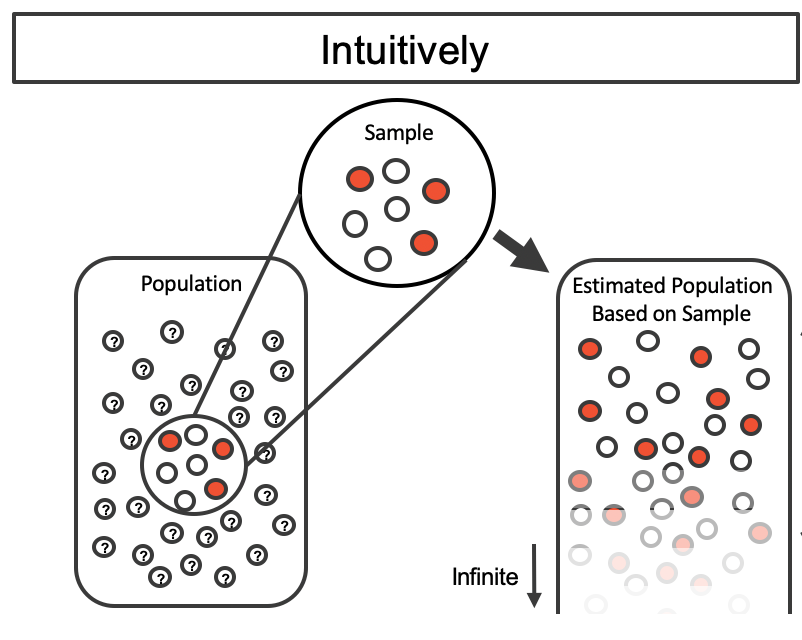

課本圖：左邊的母體（Population）裡每顆彈珠都是問號；從中取得的樣本（Sample）有3顆紅色、4顆白色；右邊是依樣本建立的估計母體（Estimated Population Based on Sample），紅白比例與樣本相同，向下無限延伸。

- 母體（Population）的組成未知，圖中以問號表示。
- 樣本（Sample）有 7 顆彈珠：3 顆紅、4 顆白。
- 依樣本的比例建立「估計的母體」（Estimated Population）：紅 3/7、白 4/7，數量無限多（Infinite）。

**樣本是我們對母體最好的估計。**

[IMS 2e](https://openintro-ims.netlify.app/foundations-bootstrapping) §12.1.2；Figure 12.1（課本原圖）

## 從估計的母體重複抽樣

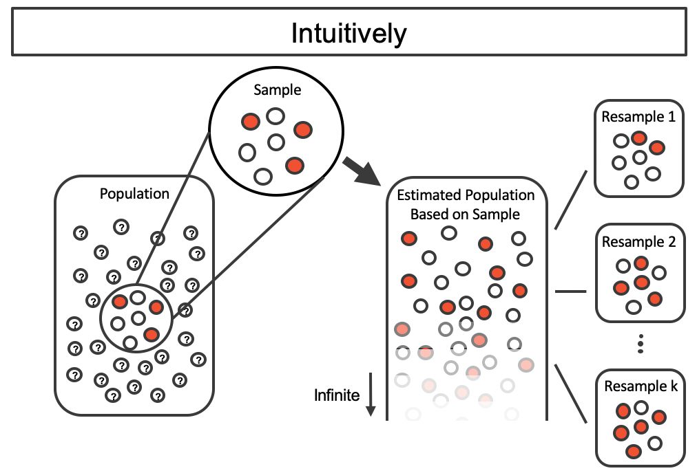

課本圖：在前一張圖的右側，從估計的母體抽出重抽樣本1、重抽樣本2到重抽樣本k（Resample 1、2、k），每份7顆，紅色顆數各不相同。

- 從估計的母體抽出許多份重抽樣本（Resample 1、2、…、k）。
- 每份的大小與原樣本相同：7 顆。
- 各份的紅色顆數不同，差異完全來自抽樣的隨機性。

**重抽樣本之間的差異，顯示樣本與樣本之間會差多少。**

[IMS 2e](https://openintro-ims.netlify.app/foundations-bootstrapping) §12.1.2；Figure 12.2（課本原圖）

## 每份重抽樣本算一個比例

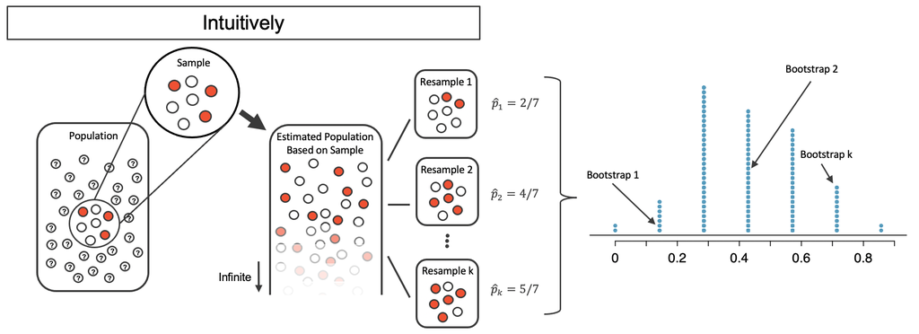

課本圖：每份重抽樣本各算一個紅色比例，例如2/7、4/7、5/7；右側把所有比例畫成點圖，橫軸由0到0.8，箭頭標出第1、第2與第k份重抽樣本落在哪一疊點上。

每份重抽樣本各算一個統計量（此處為比例 $\hat p$）；全部畫在一起，就是 bootstrap 分布（bootstrap distribution）。

[IMS 2e](https://openintro-ims.netlify.app/foundations-bootstrapping) §12.1.2；Figure 12.3（課本原圖）

## 實際做法：從樣本有放回重抽

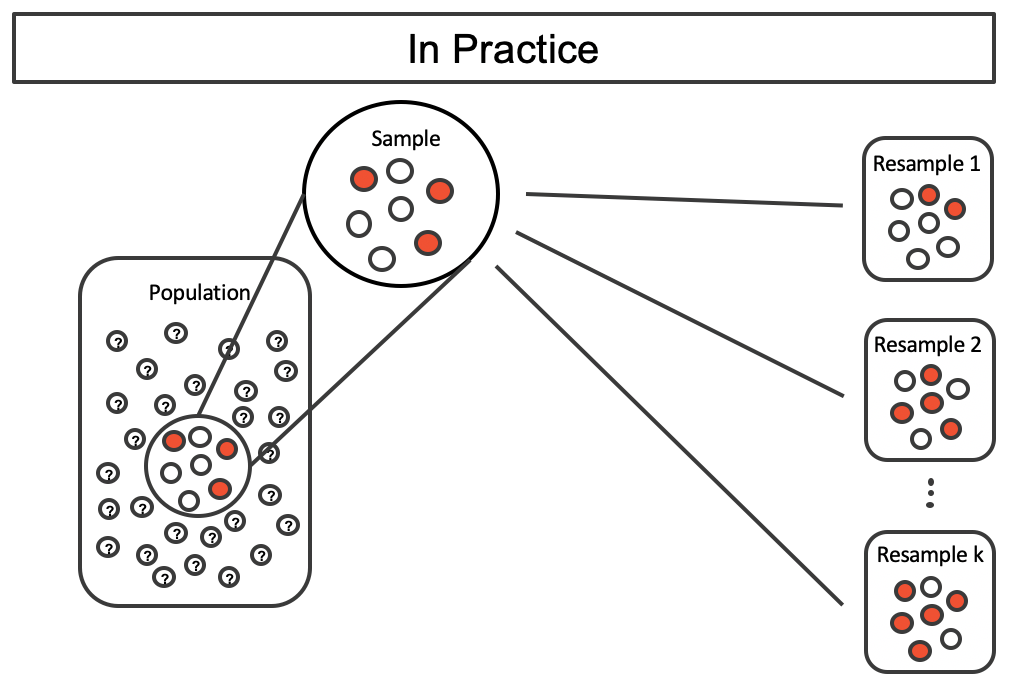

課本圖，標題為實際做法（In Practice）：不再畫估計的母體，改由樣本直接連到重抽樣本1、2到k；每份仍是7顆，紅色顆數各不相同。

- 電腦難以處理無限大的母體。
- 實際做法（In Practice）：直接從原樣本抽，每抽一顆就放回（with replacement）。
- 原樣本始終不變，所以過程等同於從估計的母體抽樣。

**把樣本當成一袋彈珠，抽出後放回再抽。**

[IMS 2e](https://openintro-ims.netlify.app/foundations-bootstrapping) §12.1.2；Figure 12.4（課本原圖）

## 兩種做法，同一個 bootstrap 分布

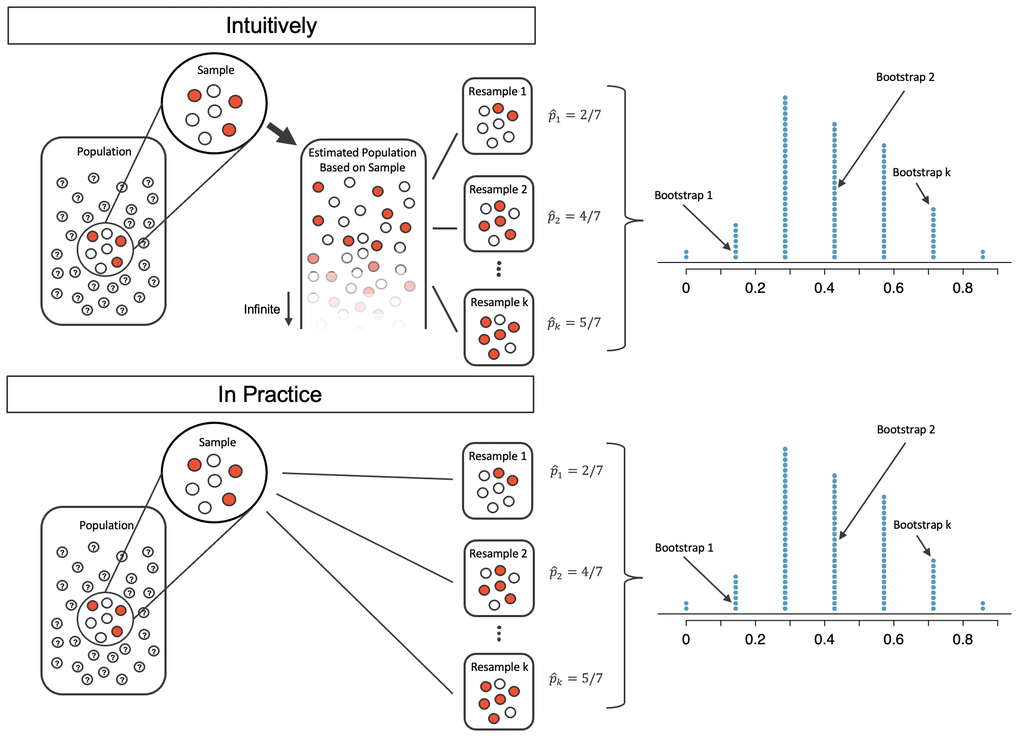

課本圖分上下兩列。上列為直覺上（Intuitively）：樣本、估計的母體、重抽樣本、各自的比例與點圖；下列為實際做法（In Practice）：由樣本直接有放回重抽，得到相同的比例與點圖。

上列（Intuitively）：先建立估計的母體，再從中抽樣。

下列（In Practice）：直接從樣本有放回重抽。

兩列右側的點圖相同：兩種做法得到同一個 bootstrap 分布。

[IMS 2e](https://openintro-ims.netlify.app/foundations-bootstrapping) §12.1.2、§12.4.1；Figure 12.5，Figure 12.8 為同一張圖（課本原圖）

## 一次重抽：有放回

- 重抽 $n$ 筆，與原樣本相同。
- 每抽一筆就放回，所以同一個觀察可以重複被抽到。
- 有些觀察這次沒被抽到。

重抽的單位是**觀察單位**。

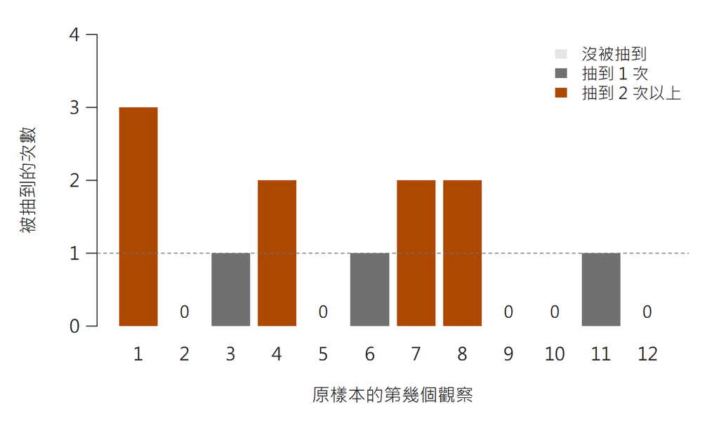

一次重抽中12個原始觀察各被抽到幾次：第1個抽到3次，第2、5、9、10、12個沒被抽到，其餘抽到1到2次；總和12。

IMS §12.1.2；本課程自製示意（12筆自編資料，seed=73）

## 重複 B 次，得到 bootstrap 分布

重抽 $B=10{,}000$ 次，每次算平均：

```r
boot_means <- replicate(
  10000,
  mean(sample(x, size = length(x),
              replace = TRUE))
)
sd(boot_means)
```

bootstrap SE $=1.059$；公式 $s/\sqrt n=1.114$。

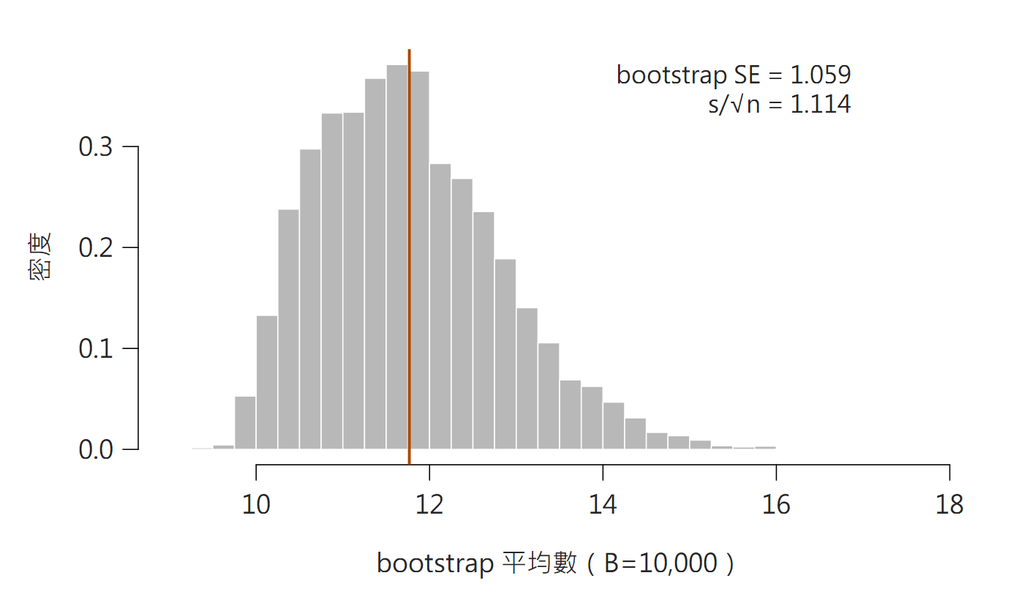

10000個bootstrap平均數的直方圖，橘線是樣本平均11.77；略為右偏，因為資料中有一個23.0的極端值。

IMS §12.1.2；本課程自製（12筆自編資料，B=10,000，seed=1008）

## 中位數也可以 bootstrap

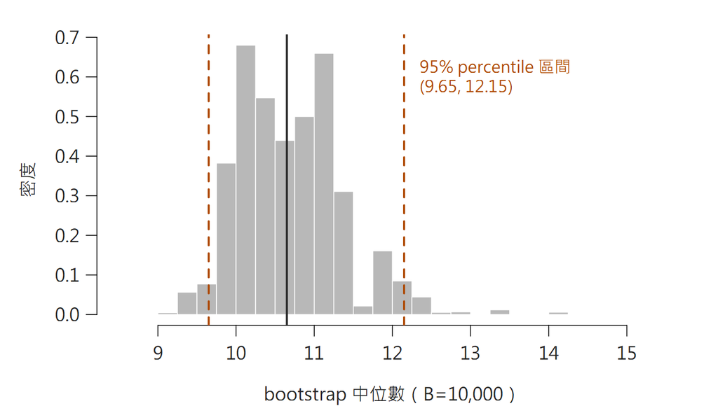

10000個bootstrap中位數的直方圖，呈階梯狀；黑線是樣本中位數，橘色虛線標出95%區間9.65到12.15。

中位數沒有簡單的 SE 公式；同一套程序，把統計量換成中位數即可。

IMS §12.1.2、§19.1；本課程自製（12筆自編資料，B=10,000，seed=1008）

## Bootstrap 的限制

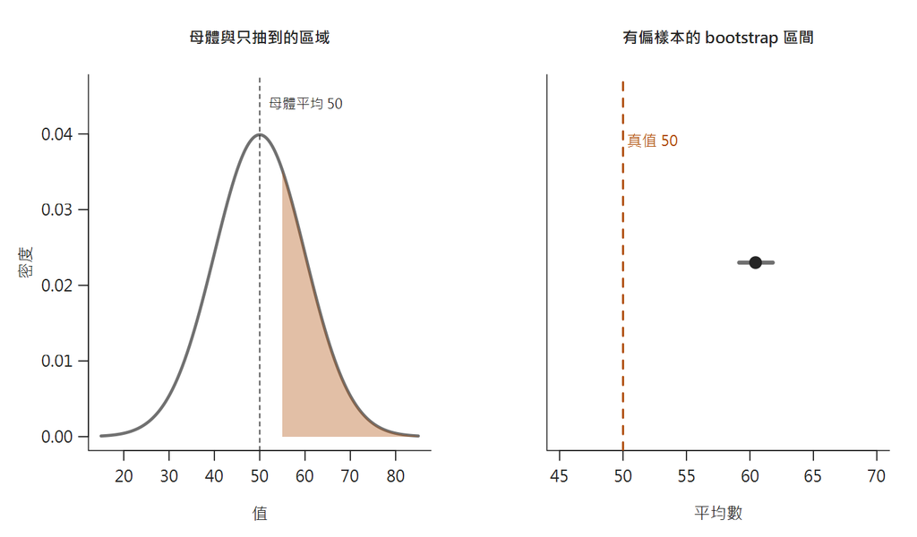

左：常態母體（平均50），橘色是只抽到的高值區域（55以上）；右：這份有偏樣本的bootstrap區間很窄，卻完全漏掉虛線標示的真值50。

Bootstrap 不是小樣本的解方，也無法補救有偏的抽樣；前提是樣本具代表性、觀察彼此獨立。

前面的 12 筆只用來說明步驟；樣本太少時，bootstrap 區間並不可靠。

IMS §19.1.5（不是小樣本的解方）；有偏抽樣為本課程自編示意（常態母體平均50、SD 10，只抽55以上，n=40，seed=74）

## Percentile 95% 區間

[figure not shown]

bootstrap平均數分布，中間95%塗橘色；兩條虛線分別在10.10與14.15。

取 bootstrap 分布的 2.5% 與 97.5% 分位，得到 95% 區間：(10.10, 14.15)。

IMS §12.3.2；本課程自製（12筆自編資料，B=10,000，seed=1008）

## 課本例子：肝臟捐贈手術的 bootstrap 區間

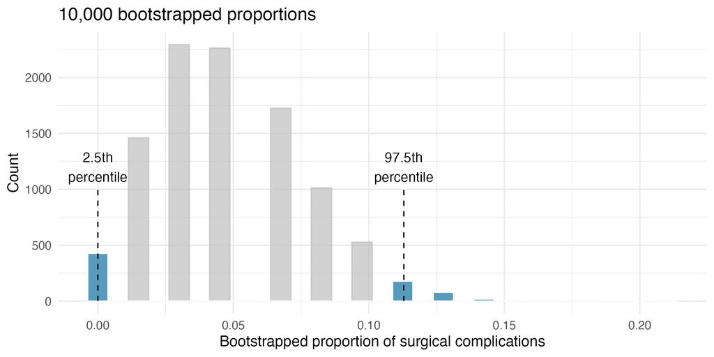

課本圖：10000個重抽比例的直方圖，橫軸是重抽得到的併發症比例，由0到0.20；兩條虛線標出第2.5百分位數0與第97.5百分位數0.113，界線外的長條為藍色。

一位醫療顧問協助過 62 例肝臟捐贈手術，其中 3 例有併發症：$\hat p=3/62=0.048$。

每次從 62 例有放回重抽 62 例，算一個比例；重複 10,000 次。

橫軸是重抽得到的併發症比例，縱軸是次數（Count）。

第 2.5 與第 97.5 百分位數（percentile）是 0 與 0.113：95% 區間為 0% 至 11.3%。

[IMS 2e](https://openintro-ims.netlify.app/foundations-bootstrapping) §12.1.2；Figure 12.6（課本原圖）；觀察性資料

## 練習 1｜敲節奏猜歌：讀出 bootstrap 區間

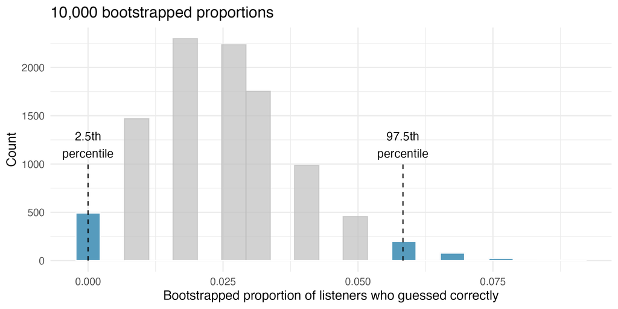

課本圖：10000個重抽比例的直方圖，橫軸是重抽得到的猜對比例，由0到約0.09；兩條虛線標出第2.5百分位數0與第97.5百分位數0.0583。

一人敲出歌曲的節奏，另一人猜歌名。約半數敲的人預期對方猜得到；120 位聽者中只有 3 位猜對，$\hat p=0.025$。

1. 由圖讀出 95% 區間。
2. 50% 在區間內嗎？

區間約為 0% 至 5.83%。50% 遠在區間之外：資料不支持「半數聽者猜得到」。

[IMS 2e](https://openintro-ims.netlify.app/foundations-bootstrapping) §12.2；Figure 12.7（課本原圖）

## SE 型區間與兩種方法比較

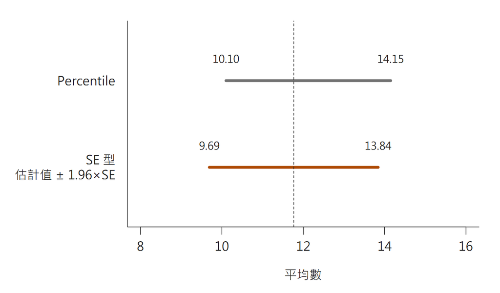

兩種95%區間：Percentile為10.10到14.15，SE型為9.69到13.84；虛線是樣本平均11.77。

SE 型區間：估計值 $\pm\,1.96\times\operatorname{SE}_{\text{boot}}$；bootstrap 分布大致對稱、呈鐘形時才適用。兩種方法相近，但不完全相同。

IMS §19.1.3（bootstrap SE 區間）、§13.6；本課程自製；本課程統一用1.96（課本 §19.1.3 用2）

## 重複很多次：25 個 95% 區間

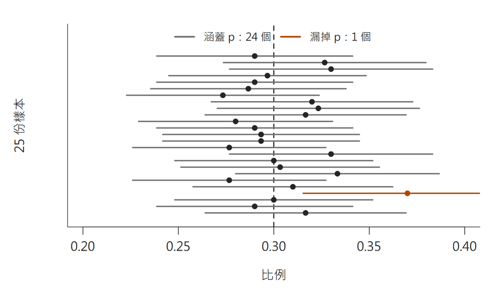

25份樣本（p等於0.30、n等於300）各算一個95%區間；24個涵蓋虛線標示的p，1個橘色區間漏掉。

95% 指的是方法重複很多次的涵蓋率；參數固定，區間隨樣本而變。

IMS §13.6.3，概念參考 Figure 13.11（25個區間漏掉1個）；本課程自製模擬（p=0.30、n=300，seed=75）；單次結果，漏掉的個數會變

## 長期涵蓋率

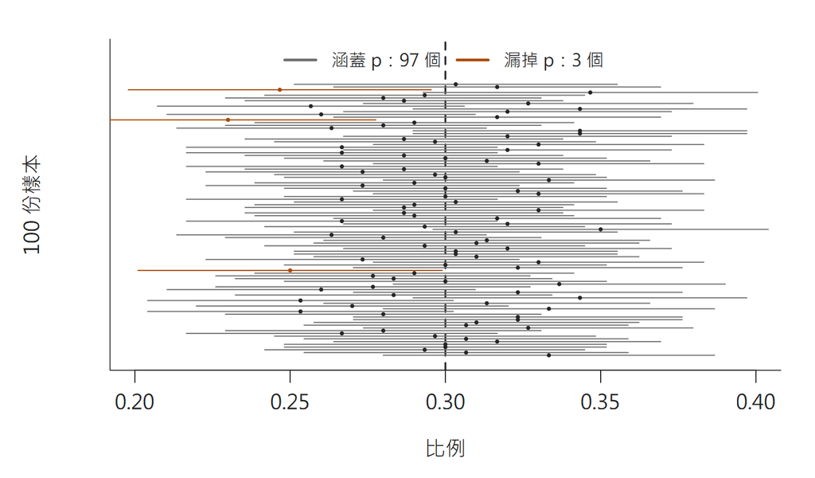

100份樣本的95%區間，97個涵蓋p，3個漏掉（橘色）。

同一個方法重複很多次，約 95% 的區間涵蓋參數。

已算出的某一個區間，不能說「有 95% 的機率含參數」：參數固定，區間要嘛含，要嘛不含。

IMS §13.6.3；本課程自製模擬（p=0.30、n=300，seed=76）；單次結果

## 區間不是個別值的範圍

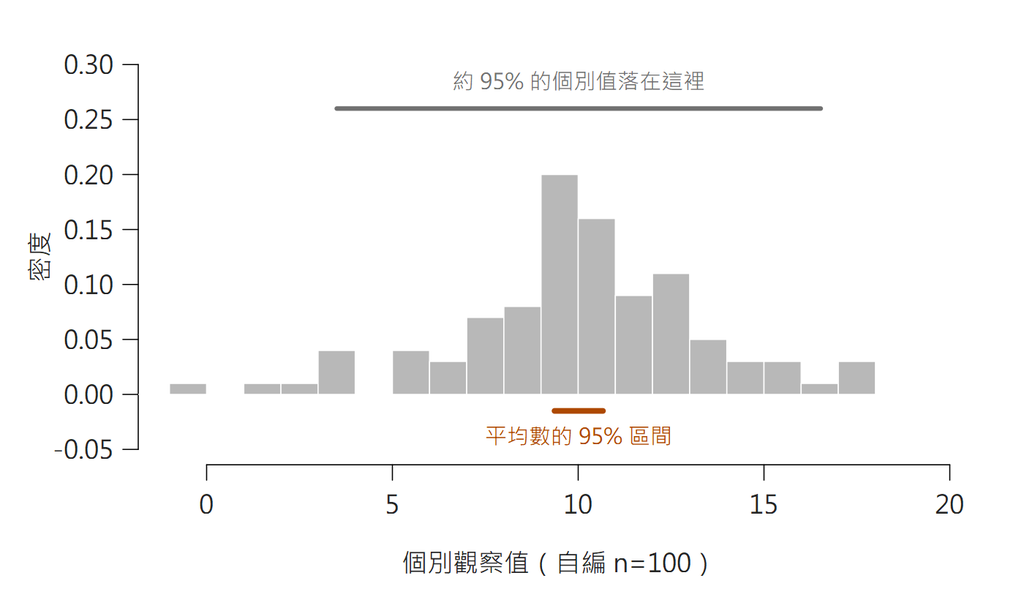

自編100筆資料的直方圖；上方灰線是約95%個別值所在的範圍，下方橘色短線是平均數的95%區間，窄很多。

平均數的信賴區間描述平均數的不確定性，不是 95% 個別值所在的範圍。

IMS §13.6.3；本課程自編數值示範（常態，平均10、SD 3，n=100，seed=77）

## 含某個值，不等於證明

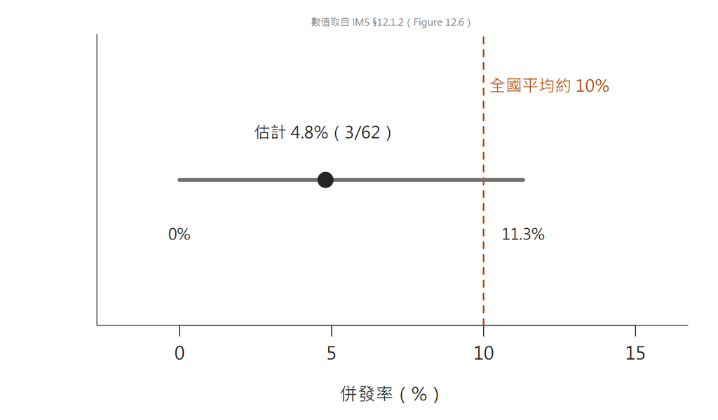

估計併發率4.8%（3/62），95%區間0%到11.3%；虛線為全國平均約10%，落在區間內。

一位醫療顧問協助過 62 例肝臟捐贈手術，其中 3 例有併發症；全國平均約 10%。

區間含全國平均，只表示資料與它相容，不是證明併發率相同；區間含 0 或不含 0，也不是證明。

這是觀察性資料，即使有差異，也不能直接下因果結論。

IMS §12.1（Figure 12.6）；醫療顧問案例，bootstrap 95% 區間；觀察性資料；圖為本課程依課本數值重繪

## 先報差異與單位：同差異、不同 n

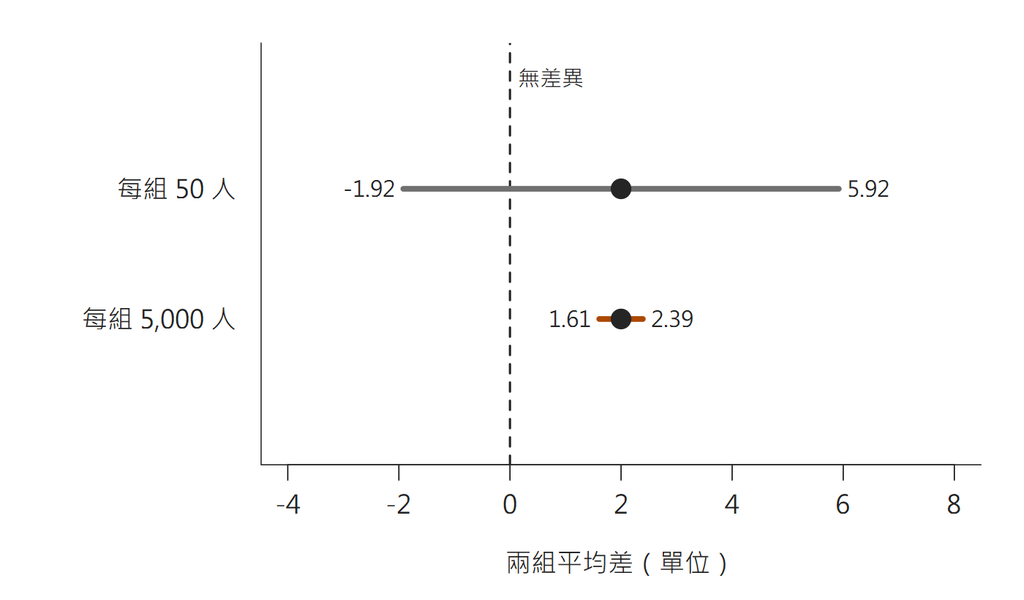

同樣的平均差2（SD等於10）：每組50人的區間是負1.92到5.92，跨過0；每組5000人的區間是1.61到2.39，不含0。

先寫差異大小與單位，再寫區間；區間窄表示估得準，不表示差異大。

本課程整理；自編數值示範（差2、SD 10；n=50與5,000）

## 標準化效果量 d

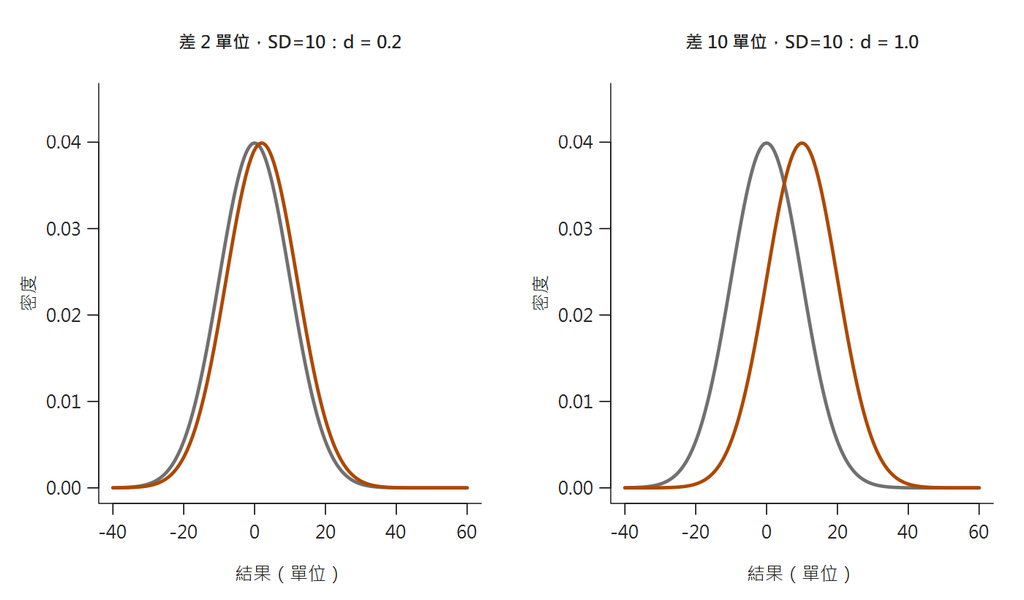

左：差2個單位、SD等於10，d等於0.2，兩條分布大幅重疊；右：差10個單位，d等於1.0，分布分得較開。

效果量（effect size）：$d=\dfrac{\text{兩組平均差}}{\text{SD}}$。多大算重要，要依領域判斷。

本課程整理（IMS §19.1、§19.2.4 選讀）；自編數值示範（SD 10）

## 顯著不等於重要

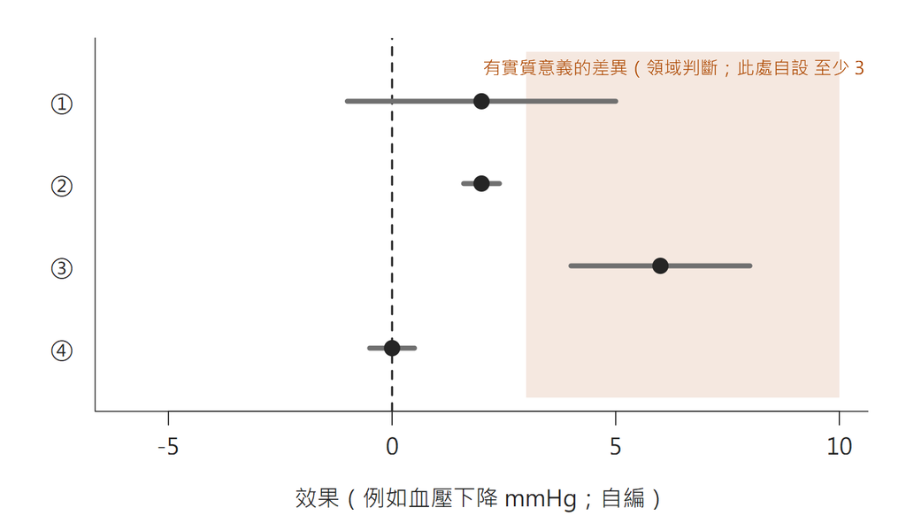

四種情境的區間與0的相對位置，粉紅色帶是有實質意義的差異（此處自設至少3）。①很寬，含0也跨進色帶；②不含0但完全在色帶外；③不含0且全在色帶內；④含0且很窄。

區間含不含 0，與差異有沒有實質重要性（practical importance），是兩件事。

本課程整理；四種情境與門檻3為自編示範值；區間是否含0僅作估計層次的描述

## 練習 2｜估計敘述與檢定敘述：支架

估計敘述說明「差多少、範圍多大」；檢定敘述只回答「有沒有差異」。

1. 「支架組與對照組的中風比例有差異。」
2. 「支架組 30 天內中風比例高出約 9.0 個百分點，95% 區間約 3.5 至 14.5 個百分點。」

哪一句是估計敘述？A 少了什麼資訊？

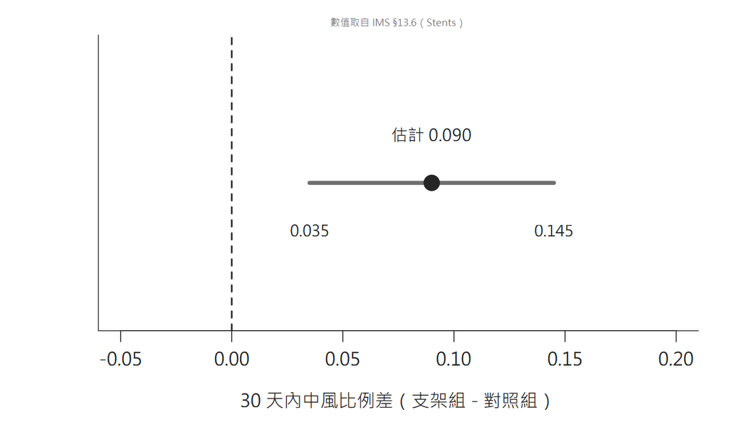

30天內中風比例差（支架組減對照組）的估計0.090，95%區間0.035到0.145，虛線是0。

B 是估計敘述。A 只說有差異，沒說差多少，也沒說範圍。

IMS §13.6 支架（Stents）研究，n=451；圖為本課程依課本數值重繪；比例差方向為支架組減對照組

## 練習 3｜點估計與區間估計的敘述：肝臟捐贈手術

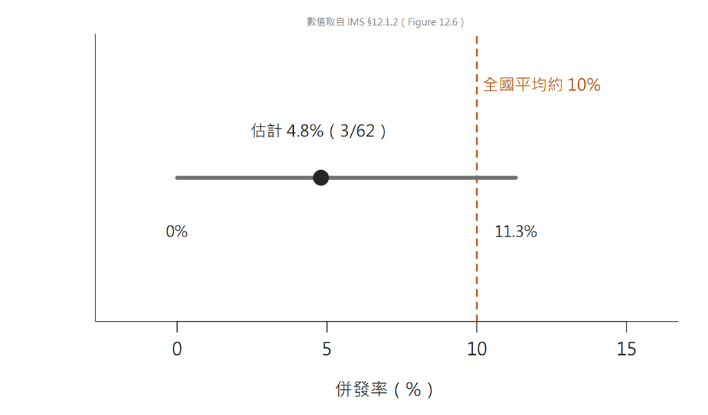

肝臟捐贈手術併發率4.8%，95%區間0%到11.3%，全國平均約10%在區間內。

原句：「併發率與全國平均無顯著差異。」

依圖改寫成兩句：點估計給一個數，區間估計給一個範圍。

| 敘述 | 改寫 |
| --- | --- |
| 點估計 | 併發率估計為 4.8%。 |
| 區間估計 | 併發率的 95% 區間為 0% 至 11.3%。 |

只看**點估計**，4.8% 比全國平均約 10% 低；**區間**含 10%，資料與全國平均相容。

IMS §12.1（Figure 12.6）；醫療顧問案例，bootstrap 95% 區間；圖為本課程依課本數值重繪

## 練習 4｜點估計與區間估計的敘述：民調

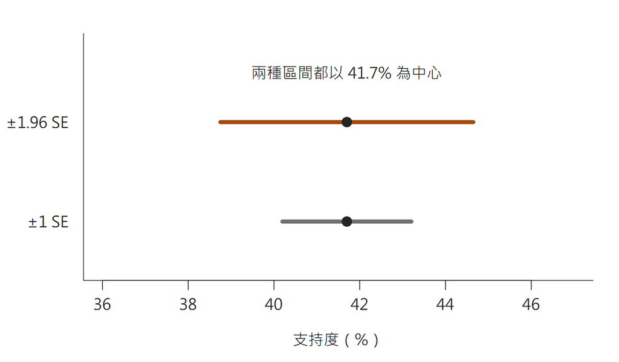

民調以41.7%為中心的±1SE與±1.96SE。

原句：「支持度高於 40%。」

依圖改寫成兩句：點估計給一個數，區間估計給一個範圍。

提示：1.96×SE 約 2.9 個百分點。

| 敘述 | 改寫 |
| --- | --- |
| 點估計 | 支持度估計為 41.7%。 |
| 區間估計 | 簡單模型下，支持度的 95% 區間約為 38.8% 至 44.6%。 |

只看**點估計**，41.7% 比 40% 高；**區間**含 40%，不能確定支持度高於 40%。

IMS §16.2；保存民調紀錄；簡單模型，非正式民調區間；同 Part 1 民調示範

## 練習 5｜哪些可能是 bootstrap 樣本？

原始樣本：**47、4、92、47、12、8**。逐一判斷下列樣本是否可能，並說明理由。

| 候選 | 重抽得到的值 |
| --- | --- |
| A | 47、47、47、47、47、47 |
| B | 92、4、13、8、47、4 |
| C | 92、47、12 |
| D | 8、47、12、12、8、4、92 |
| E | 12、4、8、8、92、12 |

**答案與解析**

- **A、E 可以**：從原樣本有放回重抽 6 筆，數值可以重複。
- **B 不可以**：13 不在原樣本內。
- **C、D 不可以**：分別只有 3 筆與 7 筆，與原樣本的 6 筆不同。

有放回重抽可以重複既有值；每份仍抽 **n 筆**。

IMS 2e §19.4，習題 19.20(a–e)，p.347；中文改寫，原始樣本與候選值沿用課本

## 練習 6｜急診平均等候時間

某急診室**母體平均等候時間**的 95% 信賴區間為 **128–147 分鐘**。

1. 報紙說「平均等候超過 3 小時」，區間支持這個說法嗎？
2. 院方說「平均等候為 2.2 小時」，區間與這個說法相容嗎？
3. 能說「95% 的病人等候 128–147 分鐘」嗎？

**答案與解析**

- **不支持**：3 小時是 180 分鐘，高於整個區間。
- **相容**：2.2 小時是 132 分鐘，落在區間內；不能因此證明平均恰為 132。
- **不能**：區間描述母體平均的不確定性，並非個別病人的等候範圍。

95% 指同一方法重複抽樣時，約 95% 的區間涵蓋母體平均。

IMS 2e §12.5，習題 12.8(a–b)，p.217；中文節選改寫；第 3 問依本週信賴區間概念延伸

## Slido｜Part 2

概念題 4–6，匿名作答。[開啟 Slido](https://app.sli.do/event/827K2CiPQiuULcdfLtqLAV)｜活動代碼 **3662547**

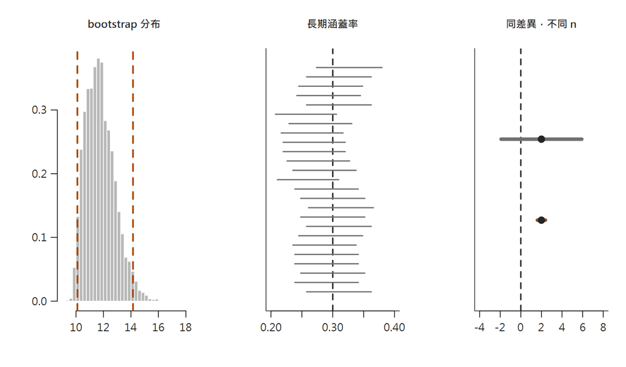

三張回顧小圖：bootstrap分布與95%界線；25個區間的長期涵蓋；同差異、不同n的區間寬度。

[figure not shown]

Week 05 Slido 作答入口 QR code；活動代碼 3662547。

Week05 Part 2 Slido；本課程自編概念題 4–6；圖為本課程自製回顧